# Factors

Abdulmajid Bakro

6/10/2021

# Factors

## forcats

the **forcats** package provides tools for working with factors ,which are R’s data structure for categorial data (datatype for factors always numeric )

```r
# klippy::klippy(position = c('center', 'right'))
library(forcats)
library(ggplot2)
library(dplyr)
```

factors : R represent categorical data with factors . A factor is an integer vector with a **levels** attribute that stores a set of mappings between integers and categorical values ,when you view a factor , R display not the integers , burt the levels associated with them  
factor(x=character(),levels,labels = levels, exclude = NA , ordered = is.ordered(x),nmax = NA)

```r
f <- factor(c('a','b','c','c','b','a'),levels = c('a','b','c') )
```

to convert a vector to a factor using as_factor()

```r
vec <- c('a','b','c','c','b','a')
fac <-as_factor(vec)
fac
```

```
## [1] a b c c b a
## Levels: a b c
```

return levels

```r
levels(fac)
```

```
## [1] "a" "b" "c"
```

structure of factors

```r
 summary(fac)
```

```
## a b c
## 2 2 2
```

```r
unclass(fac)
```

```
## [1] 1 2 3 3 2 1
## attr(,"levels")
## [1] "a" "b" "c"
```

# inspect Factors

count number of values with each levels

```r
fct_count(fac,sort =FALSE ,prop = FALSE)
```

```
## # A tibble: 3 x 2
##   f         n
##   <fct> <int>
## 1 a         2
## 2 b         2
## 3 c         2
```

```r
fct_count(iris$Species,sort =FALSE ,prop = FALSE)
```

```
## # A tibble: 3 x 2
##   f              n
##   <fct>      <int>
## 1 setosa        50
## 2 versicolor    50
## 3 virginica     50
```

check for levels in factor

```r
fct_match(fac,"a")
```

```
## [1]  TRUE FALSE FALSE FALSE FALSE  TRUE
```

return the unique values , removing duplicate

```r
fct_unique(fac)
```

```
## [1] a b c
## Levels: a b c
```

## combine Factors

fct_c(…) combine factors with different levels Also **fct_cross**

```r
fct1 <- factor(c("a","b"))
fct2 <- factor(c("c","b"))
fct_c(fct1,fct2)
```

```
## [1] a b c b
## Levels: a b c
```

fct_unify(fs, levels =lvls_union(fs)) Standardizelevels across a list of factors.

```r
fs <- list(factor("a"), factor("b"), factor(c("a", "b")))
fct_unify(fs)
```

```
## [[1]]
## [1] a
## Levels: a b
##
## [[2]]
## [1] b
## Levels: a b
##
## [[3]]
## [1] a b
## Levels: a b
```

## change order of levels

```r
faInt <- factor(c(0L, 1L, 2L, 2L, 0L, 1L))
faIntOrd <- ordered(faInt)
faIntOrd
```

```
## [1] 0 1 2 2 0 1
## Levels: 0 < 1 < 2
```

```r
faIntOrd < 2 # only given values
```

```
## [1]  TRUE  TRUE FALSE FALSE  TRUE  TRUE
```

```r
faIntOrd < 3 # NAs
```

```
## [1] NA NA NA NA NA NA
```

fct_relevel(.f, …, after = 0L) Manually reorder factor levels.

```r
fct_relevel(f, c("b", "c", "a"))
```

```
## [1] a b c c b a
## Levels: b c a
```

```r
fct_relevel(f, "a", after = 1)
```

```
## [1] a b c c b a
## Levels: b a c
```

```r
fct_relevel(f, "a", after = Inf)
```

```
## [1] a b c c b a
## Levels: b c a
```

fct_infreq(f, ordered = NA)  
Reorder levels by the frequency in which they appear in the data (highest frequency first). Also fct_inseq().

```r
f3 <- factor(c("c", "c", "a"))
fct_infreq(f3)
```

```
## [1] c c a
## Levels: c a
```

fct_inorder(f, ordered = NA) Reorder levels by order in which they appear in the data.

```r
f2 <- factor(c("b","a","c"))
fct_inorder(f2)
```

```
## [1] b a c
## Levels: b a c
```

fct_rev(f) Reverse level order.

```r
f4 <- factor(c("a","b","c"))
fct_rev(f4)
```

```
## [1] a b c
## Levels: c b a
```

fct_shift(f) Shift levels to left or right, wrapping around end.

```r
f4 <- factor(c("a","b","c"))
fct_shift(f4)
```

```
## [1] a b c
## Levels: b c a
```

fct_shuffle(f, n = 1L) Randomly permute order of factor levels. fct_shuffle(f4)

```r
f4 <- factor(c("a","b","c"))
fct_shuffle(f4)
```

```
## [1] a b c
## Levels: a b c
```

fct_reorder(.f, .x, .fun = median, …, .desc = FALSE) Reorder levels by their relationship with another variable.

```r
head(PlantGrowth)
```

```
##   weight group
## 1   4.17  ctrl
## 2   5.58  ctrl
## 3   5.18  ctrl
## 4   6.11  ctrl
## 5   4.50  ctrl
## 6   4.61  ctrl
```

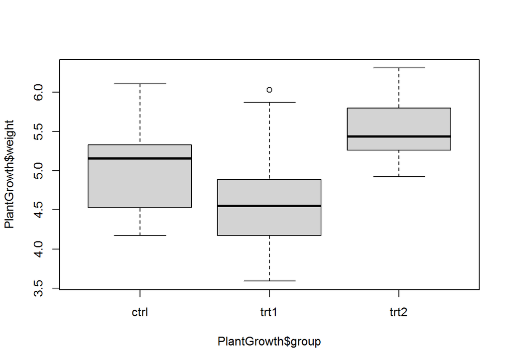

```r
boxplot(PlantGrowth$weight ~ PlantGrowth$group)
```

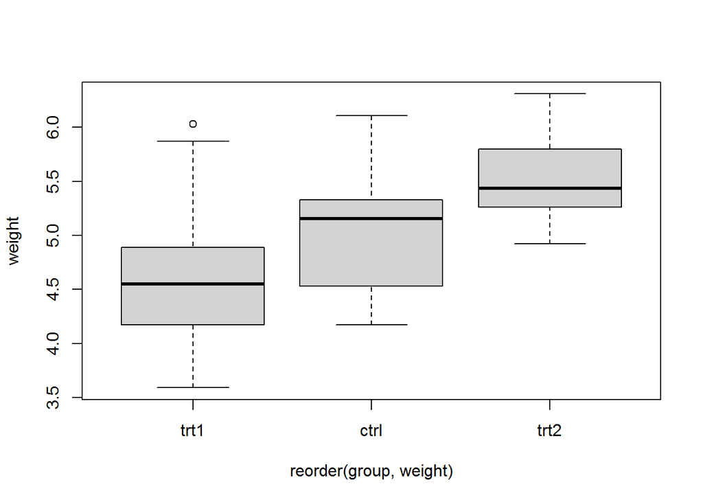

```r
boxplot(data = PlantGrowth,
weight ~ reorder(group, weight))
```

```r
faGeschl <- factor(c(rep("W", each = 10),
                     rep("M", each = 10),
                     rep("D", each = 10)))
faGeschl
```

```
##  [1] W W W W W W W W W W M M M M M M M M M M D D D D D D D D D D
## Levels: D M W
```

```r
vnGew_W <- c(58.10, 54.65, 58.03, 56.83, 60.44, 65.92, 61.38, 59.10,
             59.66, 54.65)
vnGew_M <- c(84.84, 80.02, 78.80, 82.45, 81.30, 77.47, 82.61, 85.35,
             78.41, 81.62)
vnGew_D <- c(67.53, 67.31, 72.68, 69.65, 63.38, 2.14, 63.13, 71.31,
             75.00, 69.72)
vnGew <- c(vnGew_W, vnGew_M, vnGew_D)

faGeschlReOrd <- reorder(faGeschl, vnGew, FUN = mean)
faGeschlReOrd
```

```
##  [1] W W W W W W W W W W M M M M M M M M M M D D D D D D D D D D
## attr(,"scores")
##      D      M      W
## 62.185 81.287 58.876
## Levels: W D M
```

fct_reorder2(.f, .x, .y, .fun = last2, …, .desc = TRUE) Reorder levels by their final values when plotted with two other variables.

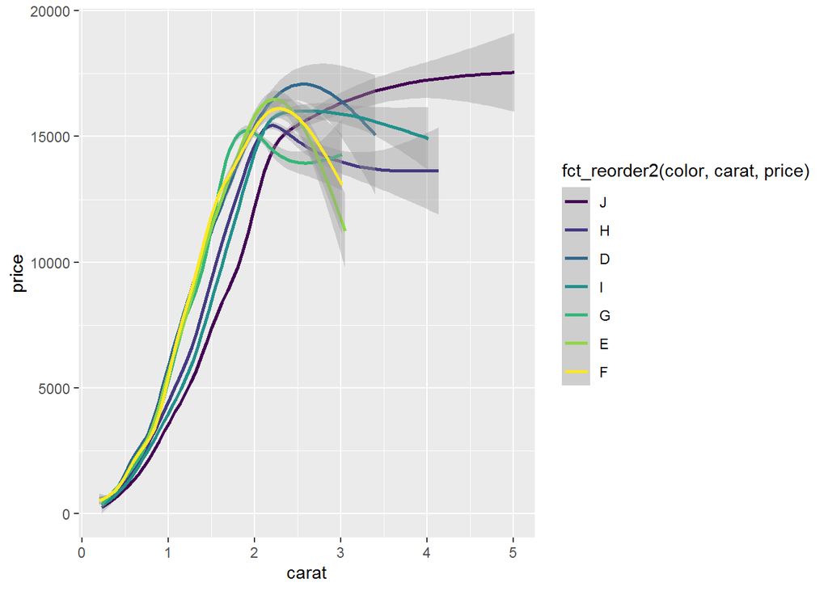

```r
ggplot(diamonds,aes(carat, price,
color = fct_reorder2(color, carat,
price))) + geom_smooth(ls = F)
```

## Change the value of levels

fct_recode(.f, …) Manually change levels. Also fct_relabel() which obeys purrr::map syntax to apply a function or expression to each level.

```r
f <- factor(c("a","b","c"))
fct_recode(f, v = "a", x = "b", z = "c")
```

```
## [1] v x z
## Levels: v x z
```

```r
fct_relabel(f, ~ paste0("x", .x))
```

```
## [1] xa xb xc
## Levels: xa xb xc
```

fct_anon(f, prefix = "") Anonymize levels with random integers.

```r
fct_anon(f)
```

```
## [1] 1 2 3
## Levels: 1 2 3
```

fct_collapse(.f, …, other_level = NULL) Collapse levels into manually defined groups.

```r
fct_collapse(f, x = c("a"))
```

```
## [1] x b c
## Levels: x b c
```

fct_lump_min(f, min, w = NULL, other_level = “Other”) Lumps together factors that appear fewer than min times. Also fct_lump_n(), fct_lump_prop(), and fct_lump_lowfreq(). fct_lump_min(f, min = 2)

```r
f2 <- factor(c("a","a","a","b","c"))
fct_lump_min(f2, min = 2)
```

```
## [1] a     a     a     Other Other
## Levels: a Other
```

fct_other(f, keep, drop, other_level = “Other”) Replace levels with “other.”

```r
fct_other(f, keep = c("a", "b"))
```

```
## [1] a     b     Other
## Levels: a b Other
```

## add or drop levels

fct_drop(f, only) Drop unused levels.

```r
f5 <- factor(c("a","b"),c("a","b","x"))
f6 <- fct_drop(f5)
f5 ; f6
```

```
## [1] a b
## Levels: a b x
```

```
## [1] a b
## Levels: a b
```

fct_expand(f, …) Add levels to a factor.

```r
fct_expand(f6, "x")
```

```
## [1] a b
## Levels: a b x
```

fct_explicit_na(f, na_level=“(Missing)”) Assigns a level to NAs to ensure they appear in plots, etc.

```r
fct_explicit_na(factor(c("a", "b", NA)))
```

```
## [1] a         b         (Missing)
## Levels: a b (Missing)
```

## operations

sampling or indexing

```r
fac[2:4]
```

```
## [1] b c c
## Levels: a b c
```

```r
fac[c(1, 3, 5)]
```

```
## [1] a c b
## Levels: a b c
```

```r
fac[-c(2,4)]
```

```
## [1] a c b a
## Levels: a b c
```

sampling using operation

```r
fac < 1   #  ‘<’ not meaningful for factors
```

```
## [1] NA NA NA NA NA NA
```

add values to factors

```r
fac <- factor(c("a","b","c"))
fac[4] <- "a"
fac
```

```
## [1] a b c a
## Levels: a b c
```

```r
fac[5] <- "Z"  # z not found in levels
fac <-fct_expand(fac,"Z")
fac[5] <- "Z"
fac
```

```
## [1] a b c a Z
## Levels: a b c Z
```

```r
faLH <- gl(n = 2, k = 3, labels = c("low", "high"))
faLH
```

```
## [1] low  low  low  high high high
## Levels: low high
```

grid or cross factors

```r
fac1 <- factor(c(1,2,3))
fac2 <- factor(c(1,2,3))
dfFactKombi <- expand.grid(fac1, fac2)
dfFactKombi
```

```
##   Var1 Var2
## 1    1    1
## 2    2    1
## 3    3    1
## 4    1    2
## 5    2    2
## 6    3    2
## 7    1    3
## 8    2    3
## 9    3    3
```

```r
intersected <- interaction(fac1, fac2)
intersected
```

```
## [1] 1.1 2.2 3.3
## Levels: 1.1 2.1 3.1 1.2 2.2 3.2 1.3 2.3 3.3
```

```r
fact1 <- factor(rep(c(1:10),3))
```

## Examples

### Months orders

```r
x2 <- c("Dec", "Apr", "Jam", "Mar")
```

```r
sort(x2)
```

```
## [1] "Apr" "Dec" "Jam" "Mar"
```

```r
month_levels <- c(
  "Jan", "Feb", "Mar", "Apr", "May", "Jun",
  "Jul", "Aug", "Sep", "Oct", "Nov", "Dec"
)
```

```r
y1 <- factor(x2, levels = month_levels)
y1
```

```
## [1] Dec  Apr  <NA> Mar
## Levels: Jan Feb Mar Apr May Jun Jul Aug Sep Oct Nov Dec
```

[output not shown]

```r
sort(y1)
```

```
## [1] Mar Apr Dec
## Levels: Jan Feb Mar Apr May Jun Jul Aug Sep Oct Nov Dec
```

[output not shown]

### Ranking

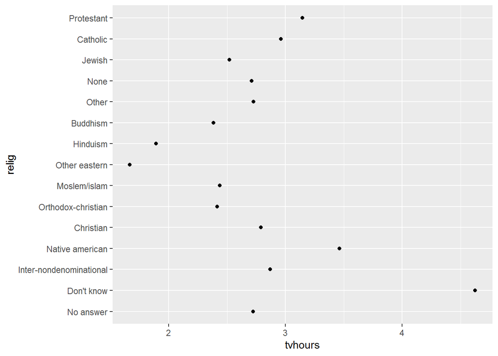

```r
relig_summary <- gss_cat %>%
  group_by(relig) %>%
  summarise(
    age = mean(age, na.rm = TRUE),
    tvhours = mean(tvhours, na.rm = TRUE),
    n = n()
  )


ggplot(relig_summary, aes(tvhours, relig)) + geom_point()
```

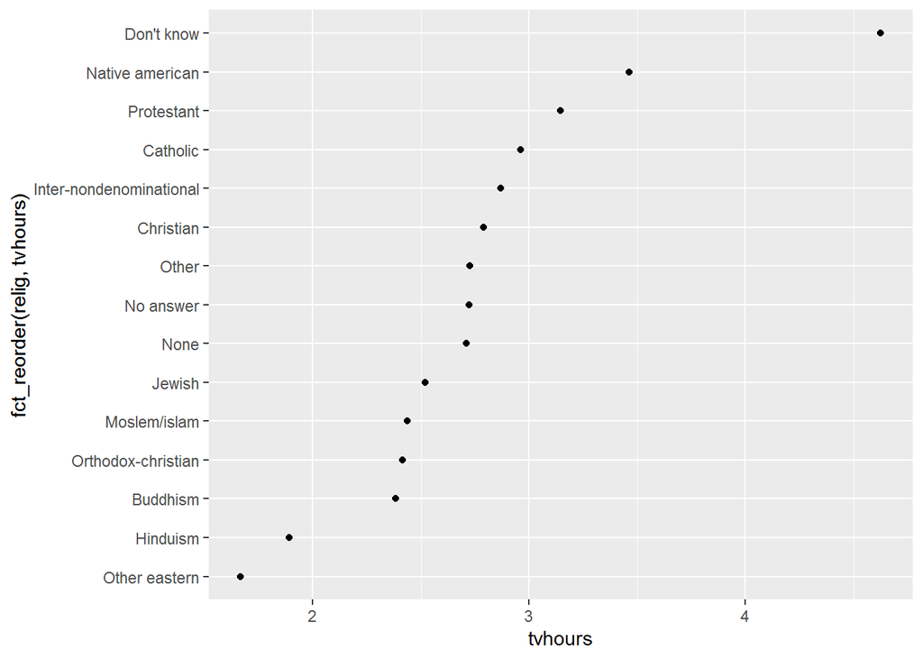

```r
ggplot(relig_summary, aes(tvhours, fct_reorder(relig, tvhours))) +
  geom_point()
```

## RECAP

### 1-what is factors

factors: R represent categorical data with factors . A factor is an integer vector with a **levels** attribute that stores a set of mappings between integers and categorical values ,when you view a factor , R display not the integers , burt the levels associated with them

### 2- initialize factors

```r
fac1 <-factor(c("SWE", "UK", "SWE", "IRE", "SWE", "THA", "IRE", "IND", "KOR", "IND"))
fac2 <-factor(c("BRA", "VEN", "MEX", "BRA", "MEX", "ARG", "CHI", "ARG", "MEX"))
fac1
```

```
##  [1] SWE UK  SWE IRE SWE THA IRE IND KOR IND
## Levels: IND IRE KOR SWE THA UK
```

```r
fac2
```

```
## [1] BRA VEN MEX BRA MEX ARG CHI ARG MEX
## Levels: ARG BRA CHI MEX VEN
```

```r
fac3 <-factor(c("BRA", "VEN", "MEX", "BRA", "MEX", "ARG", "CHI", "ARG", "MEX"),
              levels = c("ARG" , "BRA" , "CHI", "MEX", "VEN"))
fac3
```

```
## [1] BRA VEN MEX BRA MEX ARG CHI ARG MEX
## Levels: ARG BRA CHI MEX VEN
```

```r
fac4 <-factor(c("BRA", "VEN", "MEX", "BRA", "MEX", "ARG", "CHI", "ARG", "MEX"),
              levels = c("ARG" , "BRA" , "CHI"))
fac4
```

```
## [1] BRA  <NA> <NA> BRA  <NA> ARG  CHI  ARG  <NA>
## Levels: ARG BRA CHI
```

when you don’t give levels –> distinct levels ordered alphabet

when we give all levels no problem

when we give part of levels replace element that don’t have levels with NA

### 3- combine factors

```r
combinfactor <- fct_c(fac1,fac2)
fct_unify(list(fac1,fac2))
```

```
## [[1]]
##  [1] SWE UK  SWE IRE SWE THA IRE IND KOR IND
## Levels: IND IRE KOR SWE THA UK ARG BRA CHI MEX VEN
##
## [[2]]
## [1] BRA VEN MEX BRA MEX ARG CHI ARG MEX
## Levels: IND IRE KOR SWE THA UK ARG BRA CHI MEX VEN
```

```r
fct_unify(list(fac1,fac2),levels = lvls_union(list(fac1,fac2)))
```

```
## [[1]]
##  [1] SWE UK  SWE IRE SWE THA IRE IND KOR IND
## Levels: IND IRE KOR SWE THA UK ARG BRA CHI MEX VEN
##
## [[2]]
## [1] BRA VEN MEX BRA MEX ARG CHI ARG MEX
## Levels: IND IRE KOR SWE THA UK ARG BRA CHI MEX VEN
```

### 4- levels & count of levels

```r
levels(combinfactor)
```

```
##  [1] "IND" "IRE" "KOR" "SWE" "THA" "UK"  "ARG" "BRA" "CHI" "MEX" "VEN"
```

```r
nlevels(combinfactor)
```

```
## [1] 11
```

### 5- indexing

```r
fac1[1] # first element
```

```
## [1] SWE
## Levels: IND IRE KOR SWE THA UK
```

```r
fac2[1]
```

```
## [1] BRA
## Levels: ARG BRA CHI MEX VEN
```

```r
fac1[length(fac1)]  # last element
```

```
## [1] IND
## Levels: IND IRE KOR SWE THA UK
```

```r
fac2[length(fac2)]
```

```
## [1] MEX
## Levels: ARG BRA CHI MEX VEN
```

### 6- inserting

you can only insert values that found in levels (constrains),when you want to add element that

don’t have levels **first add level** than **add element**

```r
fac1[length(fac1)+1] <- "KOL"
fac1 <-fct_expand(fac1,"KOL")
fac1[length(fac1)+1] <- "KOL"
fac1
```

```
##  [1] SWE  UK   SWE  IRE  SWE  THA  IRE  IND  KOR  IND  <NA> KOL
## Levels: IND IRE KOR SWE THA UK KOL
```

### 7- Change values of levels

```r
levels(fac1)
```

```
## [1] "IND" "IRE" "KOR" "SWE" "THA" "UK"  "KOL"
```

```r
fac3 <-fct_relabel(fac1,~paste0(tolower(levels(fac1))))
fac3
```

```
##  [1] swe  uk   swe  ire  swe  tha  ire  ind  kor  ind  <NA> kol
## Levels: ind ire kor swe tha uk kol
```

```r
# fac4 <-fct_recode(fac1,tolower(levels(fac1)))
```

### 8- drop levels

you should remove all observation or records with these levels

```r
fac2
```

```
## [1] BRA VEN MEX BRA MEX ARG CHI ARG MEX
## Levels: ARG BRA CHI MEX VEN
```

```r
fac2[fac2 == "BRA" ||fac2 == "MEX"] <- NA
fct_drop(fac2)
```

```
## [1] <NA> <NA> <NA> <NA> <NA> <NA> <NA> <NA> <NA>
## Levels:
```

```r
#fac3 <- fct_drop(fac2,c("BRA","MEX"))
#fac3
```

### 9- order levels

```r
fac1 <- factor(c("c1","c3","c2","c4","IRE"))
vec <- c(1.3,1.5,1.4,1.8,1.45)
#fac3 <- reorder(fac1 ,vec~fac1)
fac3 <- fct_reorder(.f = fac1 , vec ,min)
fac3
```

```
## [1] c1  c3  c2  c4  IRE
## Levels: c1 c2 IRE c3 c4
```

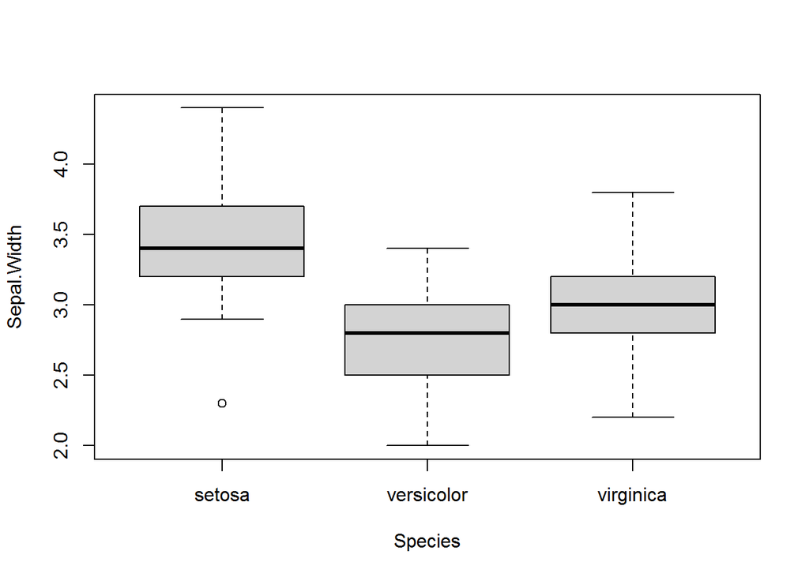

```r
boxplot(Sepal.Width ~ Species, data = iris)
```

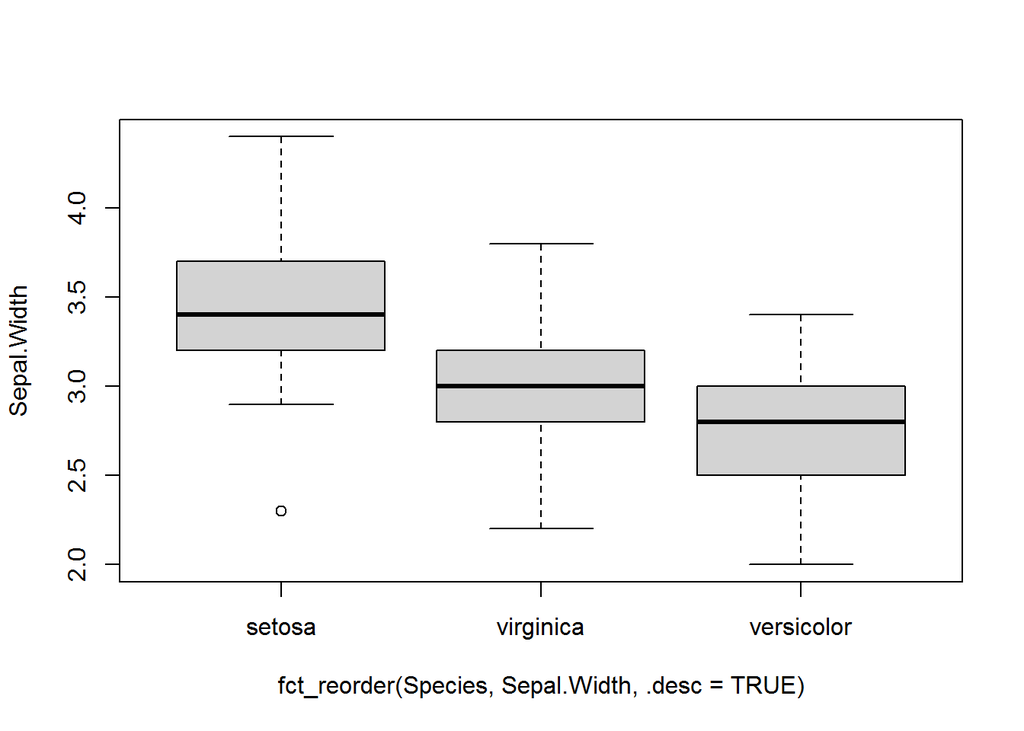

```r
boxplot(Sepal.Width ~ fct_reorder(Species, Sepal.Width, .desc = TRUE), data = iris)
```

### 10- compare operation with ordered factors

```r
fac3 <- ordered(fac3)
ind <- fac3 < "IRE";
fac3[ind]
```

```
## [1] c1 c2
## Levels: c1 < c2 < IRE < c3 < c4
```